# 1.Hypothesis

Null hypothesis: The noise complaint has not spatial clustered pattern.

Alternative hypothesis: The noise complaint has spatial clustered pattern.

Set our significance level : 0.05

# 2.Read in data

## Download data into local data file.

```r
#first Library some packages
library(tidyverse)
library(tmap)
library(rgdal)
library(broom)
library(mapview)
library(crosstalk)
library(sf)
library(sp)
library(spdep)
library(car)
library(fs)
library(janitor)
library(here)
library(readr)
library(readxl)
```

## Read in

```r
#Read in and transform it to the correct projected CRS
nyc_noise <- st_read(here::here('noisedata.geojson'))%>%
  st_transform(., crs=32618)
```

# 3.Wrangling data

## Joining data together

```r
#joining data together and count the noise point

library(sf)
points_sf_joined <-janitor::clean_names(nyc_noise)%>%
  #calculate area
  mutate(area=st_area(.))%>%
  #then density of the points per area
  mutate(density=unique_key/area)%>%
  #select density and some other variables
  dplyr::select(density, ntacode, unique_key)
```

## Map the density of joined data

We map to see the spatial distribution of joined data. From the map, it looks as though we might have some clustering. Next we will check this with Moran’s I and some other statistics

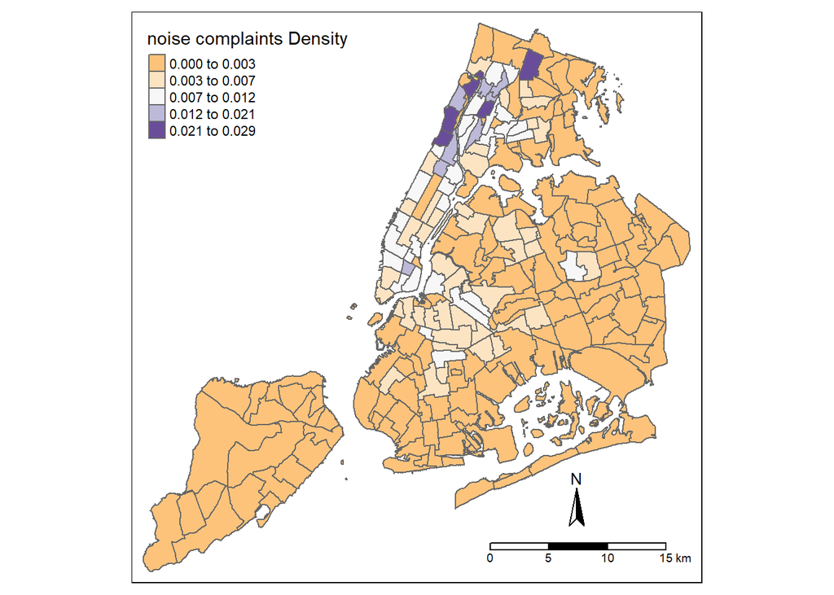

```r
tm_shape(points_sf_joined) +
    tm_polygons("density",
        style="jenks",
        palette="PuOr",
        midpoint=NA,
        popup.vars=c("ntacode", "density"),
        title="noise complaints Density")+
  tm_scale_bar(position=c(0.62,0.02),text.size=0.6)+
  tm_compass(north=0,position=c(0.73,0.1))
```

# 5.Preparing data for analysis

## Define a spatial weights matrix

In the first instance we must create a neighbours list — which is a list of all the neighbors.

```r
#create a neighbors list
NY_nb <- points_sf_joined %>%
  poly2nb(., queen=T)

#get some summary infomation
summary(NY_nb)
```

```
## Neighbour list object:
## Number of regions: 195
## Number of nonzero links: 1090
## Percentage nonzero weights: 2.866535
## Average number of links: 5.589744
## Link number distribution:
##
##  1  2  3  4  5  6  7  8  9 10 17 24 27 38
##  2  8 21 35 54 33 19 12  4  3  1  1  1  1
## 2 least connected regions:
## 31 175 with 1 link
## 1 most connected region:
## 193 with 38 links
```

We can see that the average number of neighbors is 5.59

```r
#create a spatial weights matrix with the style of row standarzised
NY_Matrix <- NY_nb %>%
  nb2mat(., style="W")
sum(NY_Matrix)
```

```
## [1] 195
```

Next we plot to see the neighborhoods.

```r
library(spdep)
#First calculate the centroids of New York
coordsNY <- points_sf_joined%>%
  st_centroid()%>%
  st_geometry()
```

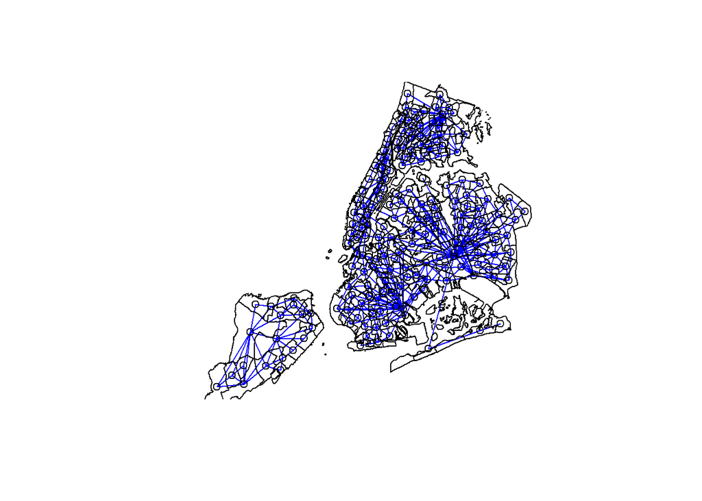

```r
#plot the neighbourhoods with a map underneath
plot(NY_nb, st_geometry(coordsNY), col="blue")
plot(points_sf_joined$geometry, add=T)
```

# 6.Analysis

## Moran I analysis

Moran’s I requires a spatial weight list type object.

Moran’s I falls between -1 and 1. And the results could be interpreted as follow: 1 = clustered, 0 = no pattern, -1 = dispersed.

```r
#create a spatial weight list
NY_LIST <- NY_nb %>%
  nb2listw(., style="W")

#calculate for the densities
I_NY_Raw_Density <- points_sf_joined %>%
  pull(density) %>%
  as.vector()%>%
  moran.test(., NY_LIST)

I_NY_Raw_Density
```

```
##
##  Moran I test under randomisation
##
## data:  .
## weights: NY_LIST
##
## Moran I statistic standard deviate = 11.607, p-value < 2.2e-16
## alternative hypothesis: greater
## sample estimates:
## Moran I statistic       Expectation          Variance
##       0.507258706      -0.005154639       0.001948985
```

From the results, The Moran’s I statistic = 0.51, which shows that we have some distinctive clustering.

## Geary’s C Analysis

Geary’s C Analysis is used to see whether similar values or dissimilar values are clustering.

Geary’s C falls between 0 and 2, and the results could be interpreted as follow: 1 means no spatial autocorrelation, <1 - positive spatial autocorrelation or similar values clustering, >1 - negative spatial autocorreation or dissimilar values clustering.

```r
C_NY_Raw_Density <- points_sf_joined %>%
  pull(density) %>%
  as.vector()%>%
  geary.test(., NY_LIST)

C_NY_Raw_Density
```

```
##
##  Geary C test under randomisation
##
## data:  .
## weights: NY_LIST
##
## Geary C statistic standard deviate = 6.5352, p-value = 3.177e-11
## alternative hypothesis: Expectation greater than statistic
## sample estimates:
## Geary C statistic       Expectation          Variance
##       0.474681823       1.000000000       0.006461444
```

From the results, The Geary’s C statistic = 0.47 which shows that similar values are clustering.

## Getis Ord analysis

General G is used to see whether high or low values are clustering.

If G > Expected = High values clustering; if G < expected = low values clustering

```r
G_NY_Raw_Density <-
  points_sf_joined %>%
  pull(density) %>%
  as.vector()%>%
  globalG.test(., NY_LIST)
G_NY_Raw_Density
```

```
##
##  Getis-Ord global G statistic
##
## data:  .
## weights: NY_LIST
##
## standard deviate = 7.5466, p-value = 2.235e-14
## alternative hypothesis: greater
## sample estimates:
## Global G statistic        Expectation           Variance
##       8.718673e-03       5.154639e-03       2.230414e-07
```

From the results, it shows G > Expected, therefore meaning that High values are tending to cluster.

## local versions of the Moran’s I statistic

Calculate to Moran’s I statistic to see where we have hot-spots.

```r
#calculate local versions
I_NY_Local_count <- points_sf_joined %>%
  pull(unique_key) %>%
  as.vector()%>%
  localmoran(., NY_LIST)%>%
  as_tibble()

I_NY_Local_Density <- points_sf_joined %>%
  pull(density) %>%
  as.vector()%>%
  localmoran(., NY_LIST)%>%
  as_tibble()

#look the output
slice_head(I_NY_Local_Density, n=5)
```

```
## # A tibble: 5 x 5
##   Ii         E.Ii          Var.Ii     Z.Ii       `Pr(z != E(Ii))`
##   <localmrn> <localmrn>    <localmrn> <localmrn> <localmrn>
## 1 0.21461563 -0.0014152304 0.05397358 0.9298764  3.524351e-01
## 2 0.05275019 -0.0010288767 0.03253870 0.2981351  7.656000e-01
## 3 5.27004602 -0.0464820984 1.40313183 4.4882690  7.180423e-06
## 4 0.26370592 -0.0022739933 0.05329675 1.1521220  2.492709e-01
## 5 0.04124705 -0.0008509205 0.01997191 0.2978869  7.657895e-01
```

Copy some columns back into our New York Data frame

```r
#Mutate some column
points_sf_joined1 <- points_sf_joined %>%
  mutate(point_count_I = as.numeric(I_NY_Local_count$Ii))%>%
  mutate(point_count_Iz =as.numeric(I_NY_Local_count$Z.Ii))%>%
  mutate(density_I =as.numeric(I_NY_Local_Density$Ii))%>%
  mutate(density_Iz =as.numeric(I_NY_Local_Density$Z.Ii))
```

## local versions of the Getis Ord statistic

Calculate to Getis Ord statistic to see where we have hot-spots.

```r
#calculate local versions
Gi_NY_Local_Density <- points_sf_joined %>%
  pull(density) %>%
  as.vector()%>%
  localG(., NY_LIST)

#look the output
head(Gi_NY_Local_Density)
```

```
## [1] -0.9298764  0.2981351  4.4882690 -1.1521220 -0.2978869 -1.5082344
```

Copy some columns back into our New York Data frame

```r
#Mutate some column
points_sf_joined <- points_sf_joined %>%
  mutate(density_G = as.numeric(Gi_NY_Local_Density))
```

# 7.Outputs

### Mapping outputs of local Moran’s I analysis

```r
#set the break mannually based on standard deviations and significant level
breaks1<-c(-1000,-2.58,-1.96,-1.65,1.65,1.96,2.58,1000)
```

Plot on an interactive map

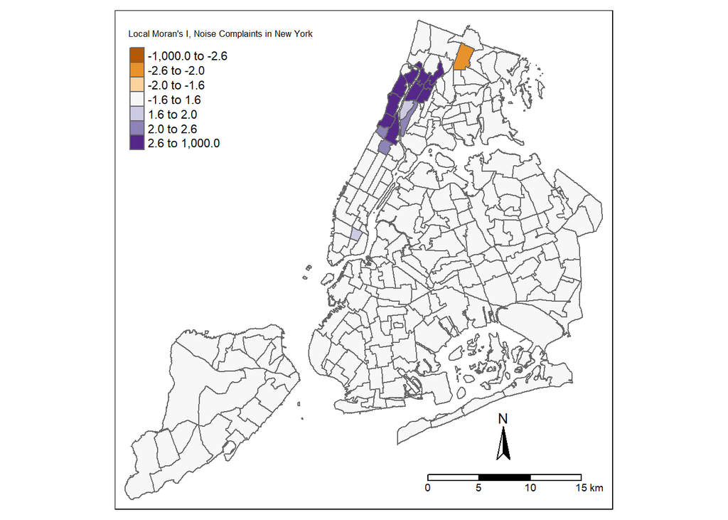

```r
#plot
tm_shape(points_sf_joined1) +
    tm_polygons("density_I",
        style="fixed",
        breaks=breaks1,
        palette="PuOr",
        midpoint=NA,
        title="Local Moran's I, Noise Complaints in New York")+
  tm_scale_bar(position=c(0.62,0.02),text.size=0.6)+
  tm_compass(north=0,position=c(0.73,0.1))
```

### Mapping outputs of local Getis Ord analysis

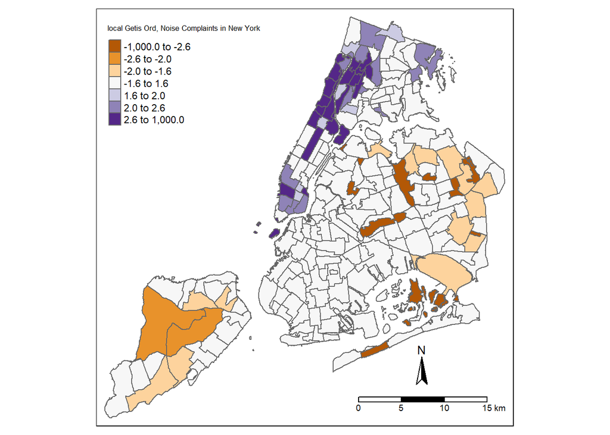

```r
tm_shape(points_sf_joined) +
    tm_polygons("density_G",
        style="fixed",
        breaks=breaks1,
        palette="PuOr",
        midpoint=NA,
        title="local Getis Ord, Noise Complaints in New York")+
  tm_scale_bar(position=c(0.62,0.02),text.size=0.6)+
  tm_compass(north=0,position=c(0.73,0.1))
```